# Chi Squared Test

Does Color Affect The Result of a Dice Roll?

Andrew Seaman

3/23/2026

```r
# Libraries
pacman::p_load(knitr, kableExtra, DT, janitor, pander, tidyverse)

# Data
data   <- read.csv("../../data/dice.csv")
dice <- data %>% select(trial, roll, color, dot, number) %>%
  drop_na() %>%
  mutate(
    color = factor(color, levels = c("Blue", "Red", "Green", "Purple")))

# Helper: Colors
helper <- data %>% select(h_die_color, h_die_hexcode, h_dot_color, h_dot_hexcode) %>% head(4)
```

```r
# Table of counts
counts <- table(
  Color = dice$color,
  Number = dice$number
  )

# Dataframe of counts
counts_df <- as.data.frame(counts)
```

## Background

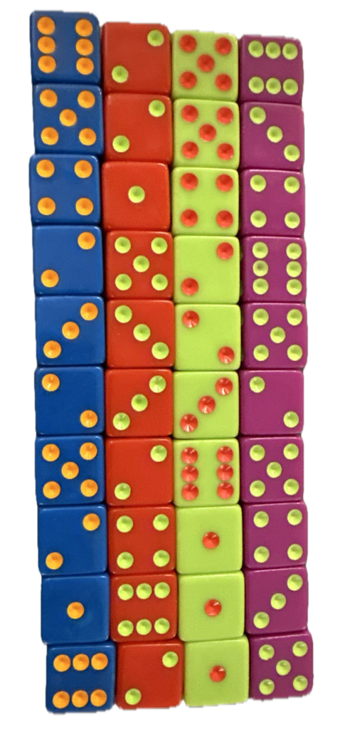

Figure 1.  
Colored Dice Sets

##### **Introduction**

From the popular dice based game Tenzi, four sets of 10 six-side colored dice ( **“blue”**, **“red”**, **“green”**, and **“purple”**; see *Figure 1*.) are used to play the game. The company’s website explains,

> The world’s fastest game! Everyone gets ten dice. Someone says, “Go.” Then everyone rolls as fast as they can until someone gets all their dice on the same number and shouts “TENZI.” Lots of different ways to play. A fun, fast frenzy for the whole family!

##### **Question**

Are the **`color`** of a die and the **`count`** of the numbers rolled **independent variables**?

##### **Prodcedure**

Clearly achieving a satisfactory sample size, **15 trials** $(t)$ were conducted where the four dice sets $(n_t = 40_\text{dice})$ were rolled all together in a dish $(n = 600_\text{rolls})$. The die **`color`** and **`number rolled`** were recorded for each die. The data were then aggregated into a table of counts with *Color* the row header and *Count* the column header.

**Table of Counts - Dice Roll Data**

```r
knitr::kable(
  counts,
  col.names = colnames(counts),
  align = "l",
  row.names = TRUE
  ) |>
  kableExtra::kable_styling(full_width = FALSE, position = "left") |>
  kableExtra::column_spec(1, width = "100px") |>
  kableExtra::column_spec(2:7, width = "50px")
```

|  | 1 | 2 | 3 | 4 | 5 | 6 |
| --- | --- | --- | --- | --- | --- | --- |
| Blue | 23 | 36 | 17 | 26 | 21 | 27 |
| Red | 24 | 25 | 23 | 26 | 28 | 24 |
| Green | 32 | 32 | 19 | 16 | 24 | 27 |
| Purple | 17 | 29 | 26 | 25 | 25 | 28 |

## Data

```r
#remove one unused row
dt_full_data <- dice %>%
  select(-dot) %>%
  rename(
    Trial = trial,
    Roll = roll,
    Color = color,
    Number = number
  )
```

### Sample Data

Randomly, 10 rows were picked (see code below) to produce a *pseudo* random sample for our intents and purposes representative of the data. For full context, click the next tab to view, search, and filter the full data set (600 rows).

```r
# Approximately representative row sample
slice_sample(dt_full_data,n=10) %>%
  pander()
```

| Trial | Roll | Color | Number |
| --- | --- | --- | --- |
| 1 | 31 | Purple | 1 |
| 8 | 304 | Green | 3 |
| 15 | 600 | Purple | 2 |
| 1 | 3 | Blue | 5 |
| 11 | 402 | Blue | 2 |
| 14 | 560 | Purple | 2 |
| 4 | 140 | Red | 5 |
| 8 | 291 | Red | 4 |
| 1 | 17 | Red | 3 |
| 13 | 511 | Purple | 2 |

### Full Data

```r
#full data
datatable(
  dt_full_data,
  options = list(
    #pages
    lengthMenu = list(c(5,10,40,120, -1), c("5","10","40","120", "All")),
    #col width
    autoWidth = TRUE
  ))
```

|  | Trial | Roll | Color | Number |
| --- | --- | --- | --- | --- |
| 1 | 1 | 1 | Blue | 1 |
| 2 | 1 | 2 | Blue | 4 |
| 3 | 1 | 3 | Blue | 5 |
| 4 | 1 | 4 | Blue | 5 |
| 5 | 1 | 5 | Blue | 5 |
| 6 | 1 | 6 | Blue | 1 |
| 7 | 1 | 7 | Blue | 1 |
| 8 | 1 | 8 | Blue | 2 |
| 9 | 1 | 9 | Blue | 3 |
| 10 | 1 | 10 | Blue | 6 |

[output cut: 590 more lines]

## Chi Square Test

**Test Results:**

```r
# Chi-Square Test
test_results <- chisq.test(counts)
test_results %>% pander()
```

Pearson’s Chi-squared test: `counts`

| Test statistic | df | P value |
| --- | --- | --- |
| 13.58 | 15 | 0.5577 |

**Expected:**

```r
test_results$expected %>% pander()
```

|  | 1 | 2 | 3 | 4 | 5 | 6 |
| --- | --- | --- | --- | --- | --- | --- |
| **Blue** | 24 | 30.5 | 21.25 | 23.25 | 24.5 | 26.5 |
| **Red** | 24 | 30.5 | 21.25 | 23.25 | 24.5 | 26.5 |
| **Green** | 24 | 30.5 | 21.25 | 23.25 | 24.5 | 26.5 |
| **Purple** | 24 | 30.5 | 21.25 | 23.25 | 24.5 | 26.5 |

**Residuals**

```r
test_results$residuals %>% pander()
```

|  | 1 | 2 | 3 | 4 | 5 | 6 |
| --- | --- | --- | --- | --- | --- | --- |
| **Blue** | -0.2041 | 0.9959 | -0.922 | 0.5703 | -0.7071 | 0.09713 |
| **Red** | 0 | -0.9959 | 0.3796 | 0.5703 | 0.7071 | -0.4856 |
| **Green** | 1.633 | 0.2716 | -0.4881 | -1.504 | -0.101 | 0.09713 |
| **Purple** | -1.429 | -0.2716 | 1.03 | 0.3629 | 0.101 | 0.2914 |

> **Graphic**

```r
# Color Lists
die_hexcodes <- helper$h_die_hexcode
names(die_hexcodes) <- helper$h_die_color

dot_hexcodes <- helper$h_dot_hexcode
names(dot_hexcodes) <- helper$h_dot_color

# Values
max_count <- max(table(dice$color, dice$number))
```

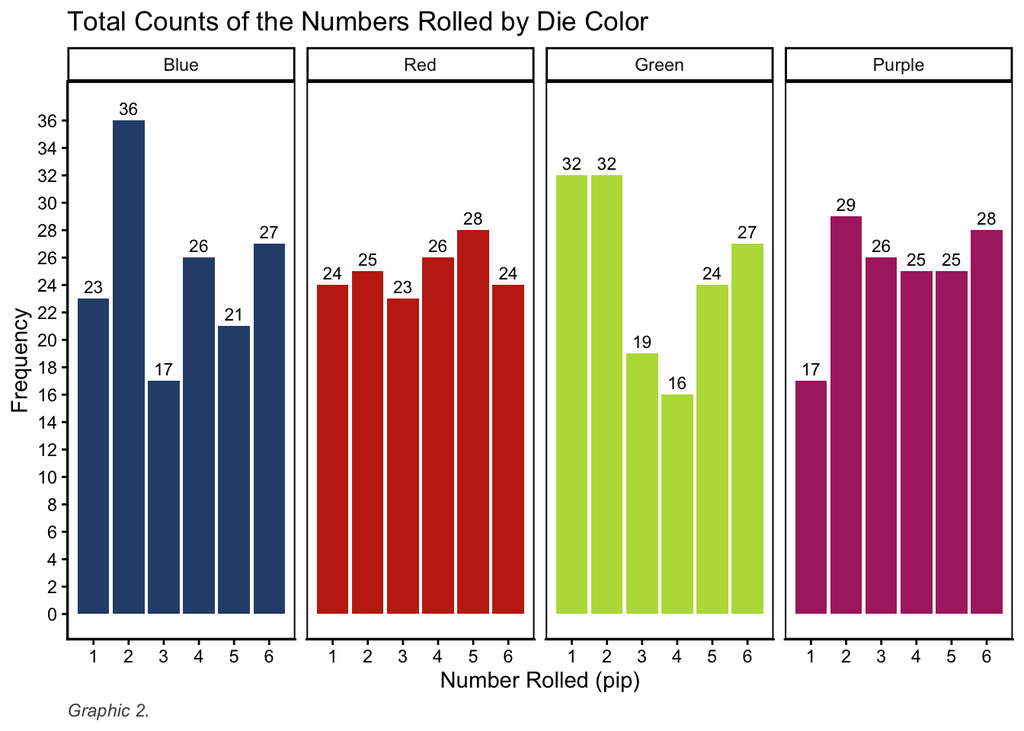

```r
ggplot(dice, aes(x = number, fill = color)) +
  labs(
    title = "Total Counts of the Numbers Rolled by Die Color",
    y = "Frequency",
    x = "Number Rolled (pip)",
    fill = "Die Color",
    caption = "Graphic 2."
  ) +
  geom_bar(position = "stack") +
  facet_wrap(~ color, ncol = 4) +
  geom_text(
    stat = "count",
    aes(label = after_stat(count)),
    vjust = -0.5,
    size = 3
  ) +
  scale_fill_manual(values = die_hexcodes) +
  scale_x_continuous(breaks = c(1,2,3,4,5,6))+
  scale_y_continuous(
    limits = c(0, max_count + 1),
    breaks = seq(0, max_count + 1, by = 2)
  ) +
  theme_classic()+
  theme(
    plot.caption = element_text(hjust = 0, color="gray30", face="italic"),
    legend.position = "none",
    panel.background = element_rect(fill = NULL, color = "black", linewidth = .7)
  )
```

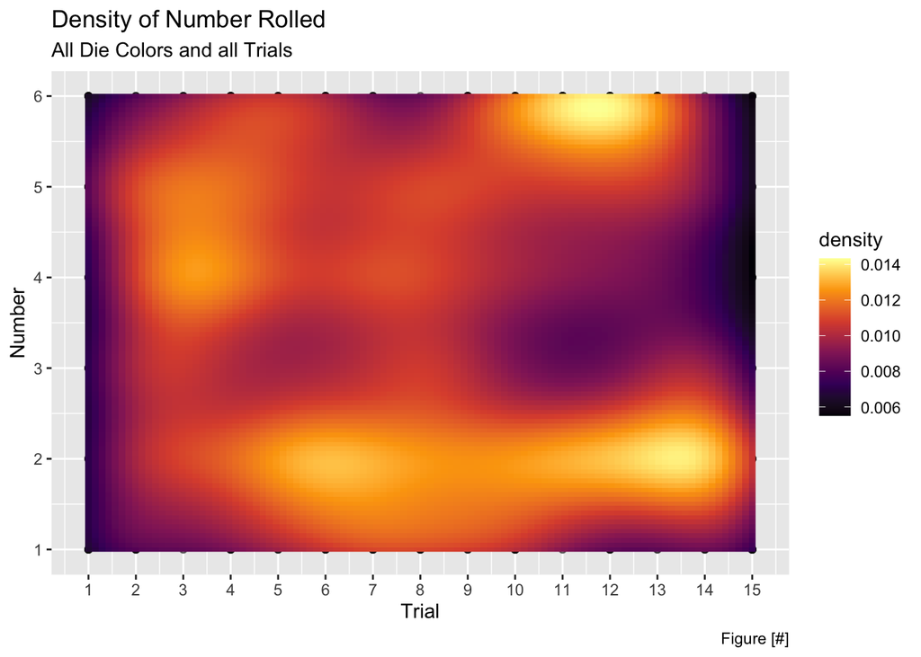

```r
# Base
scatterplot_heatmap <- ggplot(dice, aes(x=trial, y=number)) +
  geom_point(alpha = 0.3) +
  stat_density_2d(
    aes(fill = after_stat(density)),
    geom = "raster",
    contour = FALSE
    ) +
  scale_fill_viridis_c(option = "inferno") + # or: "viridis", "magma", "plasma", "inferno", "cividis", "turbo"
  scale_y_continuous(breaks=1:6) +
  scale_x_continuous(breaks = 1:15)


# All together (not faceted by die `color`)
scatterplot_heatmap + #show
  labs(
    title = "Density of Number Rolled",
    subtitle = "All Die Colors and all Trials",
    x = "Trial",
    y = "Number",
    caption = "Figure [#]"
  )
```

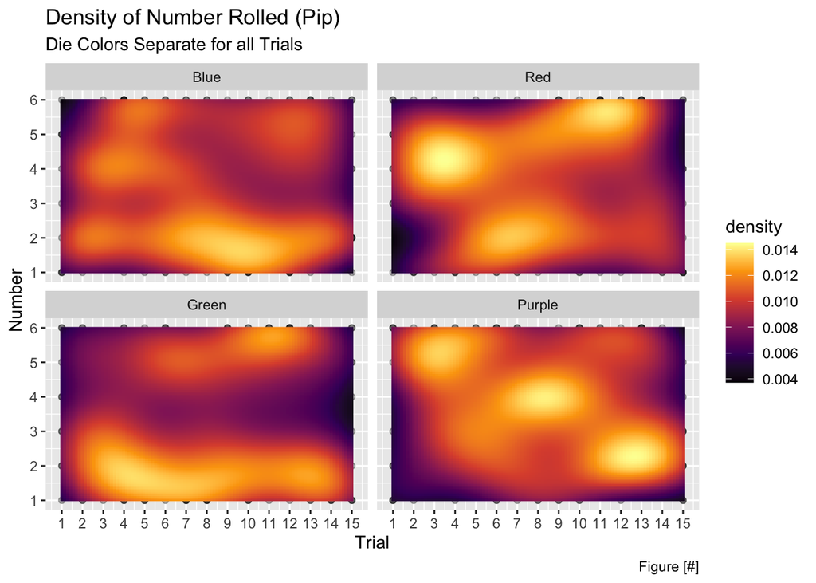

```r
# Faceted  (by die `color`)
scatterplot_heatmap_faceted <- scatterplot_heatmap +
  facet_wrap(~ color) +
    labs(
    title = "Density of Number Rolled (Pip)",
    subtitle = "Die Colors Separate for all Trials",
    x = "Trial",
    y = "Number",
    caption = "Figure [#]"
  )
scatterplot_heatmap_faceted #show
```

## Exploration

### Hide

*Click a tab to view more.*

### `glimpse()`

#### **Raw data**

```r
glimpse(dice) %>% pander()
```

Rows: 600 Columns: 5 $ trial 1, 1, 1, 1, 1, 1, 1, 1, 1, 1, 1, 1, 1, 1, 1, 1, 1, 1, 1, 1, 1, … $ roll 1, 2, 3, 4, 5, 6, 7, 8, 9, 10, 11, 12, 13, 14, 15, 16, 17, 18, … $ color Blue, Blue, Blue, Blue, Blue, Blue, Blue, Blue, Blue, Blue, Red… $ dot “Orange”, “Orange”, “Orange”, “Orange”, “Orange”, “Orange”, “Or… $ number 1, 4, 5, 5, 5, 1, 1, 2, 3, 6, 3, 4, 4, 5, 5, 1, 3, 5, 6, 6, 2, …

| trial | roll | color | dot | number |
| --- | --- | --- | --- | --- |
| 1 | 1 | Blue | Orange | 1 |
| 1 | 2 | Blue | Orange | 4 |
| 1 | 3 | Blue | Orange | 5 |
| 1 | 4 | Blue | Orange | 5 |
| 1 | 5 | Blue | Orange | 5 |
| 1 | 6 | Blue | Orange | 1 |
| 1 | 7 | Blue | Orange | 1 |
| 1 | 8 | Blue | Orange | 2 |
| 1 | 9 | Blue | Orange | 3 |
| 1 | 10 | Blue | Orange | 6 |
| 1 | 11 | Red | Green | 3 |
| 1 | 12 | Red | Green | 4 |
| 1 | 13 | Red | Green | 4 |
| 1 | 14 | Red | Green | 5 |
| 1 | 15 | Red | Green | 5 |
| 1 | 16 | Red | Green | 1 |
| 1 | 17 | Red | Green | 3 |
| 1 | 18 | Red | Green | 5 |
| 1 | 19 | Red | Green | 6 |
| 1 | 20 | Red | Green | 6 |
| 1 | 21 | Green | Red | 2 |
| 1 | 22 | Green | Red | 2 |
| 1 | 23 | Green | Red | 3 |
| 1 | 24 | Green | Red | 3 |
| 1 | 25 | Green | Red | 4 |
| 1 | 26 | Green | Red | 1 |
| 1 | 27 | Green | Red | 4 |
| 1 | 28 | Green | Red | 5 |
| 1 | 29 | Green | Red | 6 |
| 1 | 30 | Green | Red | 6 |

[output cut: 570 more lines]

#### **Table: Counts**

```r
glimpse(counts) %>% pander()
```

‘table’ int [1:4, 1:6] 23 24 32 17 36 25 32 29 17 23 … - attr(*, “dimnames”)=List of 2 ..$ Color : chr [1:4] “Blue” “Red” “Green” “Purple” ..$ Number: chr [1:6] “1” “2” “3” “4” …

|  | 1 | 2 | 3 | 4 | 5 | 6 |
| --- | --- | --- | --- | --- | --- | --- |
| **Blue** | 23 | 36 | 17 | 26 | 21 | 27 |
| **Red** | 24 | 25 | 23 | 26 | 28 | 24 |
| **Green** | 32 | 32 | 19 | 16 | 24 | 27 |
| **Purple** | 17 | 29 | 26 | 25 | 25 | 28 |

#### **Dataframe: Counts**

```r
glimpse(counts_df) %>% pander()
```

Rows: 24 Columns: 3 $ Color Blue, Red, Green, Purple, Blue, Red, Green, Purple, Blue, Red, … $ Number 1, 1, 1, 1, 2, 2, 2, 2, 3, 3, 3, 3, 4, 4, 4, 4, 5, 5, 5, 5, 6, … $ Freq 23, 24, 32, 17, 36, 25, 32, 29, 17, 23, 19, 26, 26, 26, 16, 25,…

| Color | Number | Freq |
| --- | --- | --- |
| Blue | 1 | 23 |
| Red | 1 | 24 |
| Green | 1 | 32 |
| Purple | 1 | 17 |
| Blue | 2 | 36 |
| Red | 2 | 25 |
| Green | 2 | 32 |
| Purple | 2 | 29 |
| Blue | 3 | 17 |
| Red | 3 | 23 |
| Green | 3 | 19 |
| Purple | 3 | 26 |
| Blue | 4 | 26 |
| Red | 4 | 26 |
| Green | 4 | 16 |
| Purple | 4 | 25 |
| Blue | 5 | 21 |
| Red | 5 | 28 |
| Green | 5 | 24 |
| Purple | 5 | 25 |
| Blue | 6 | 27 |
| Red | 6 | 24 |
| Green | 6 | 27 |
| Purple | 6 | 28 |

### Not Using

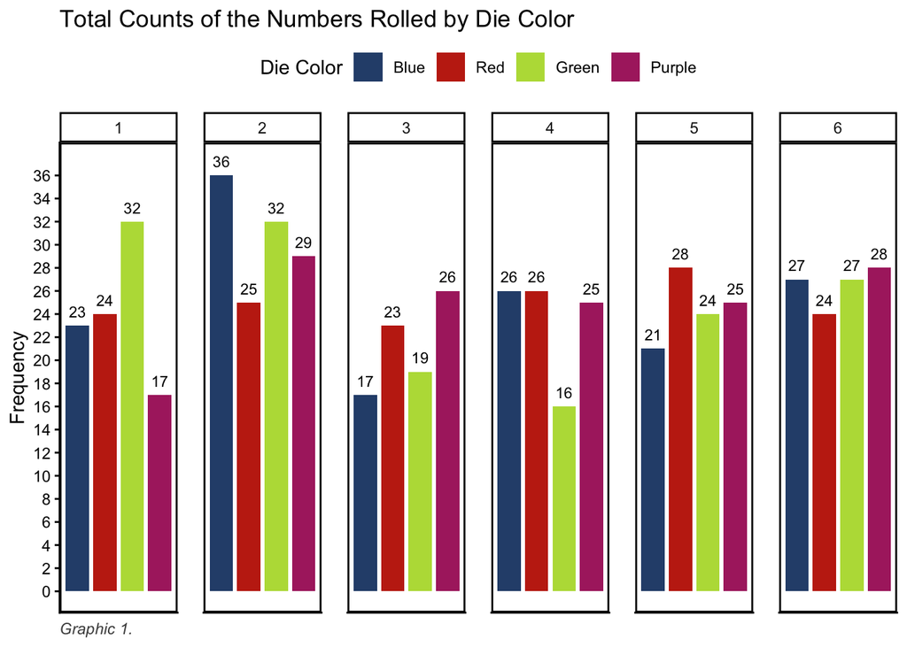

```r
ggplot(dice, aes(x = color, fill = color)) +
  labs(
    title = "Total Counts of the Numbers Rolled by Die Color",
    y = "Frequency",
    x = "Die Color",
    fill = "Die Color",
    caption = "Graphic 1."
  ) +
  geom_bar(width = .85) +
  facet_wrap(~ number, ncol = 6) +
  geom_label(
    stat = "count",
    aes(label = after_stat(count)),
    vjust = -0.2,
    size = 3,
    fill = NULL,
    color = "black",
    alpha = .7,
    linewidth = 0,
    # position = position_stack(vjust = .5)
    position = position_dodge(1.3)
  ) +
  scale_fill_manual(values = die_hexcodes) +
  scale_y_continuous(
    limits = c(0, max_count + 1),
    breaks = seq(0, max_count + 1, by = 2)
  ) +
  scale_x_discrete(expand = c(0, 0)) +
  theme_classic() +
  theme(
    plot.caption = element_text(hjust = 0, color="gray30", face="italic"),
    legend.position = "top",
    axis.text.x = element_blank(),
    axis.title.x = element_blank(),
    axis.ticks.x = element_blank(),
    panel.border = element_rect(color = "black", fill = NA, linewidth = 1),
    panel.spacing = unit(1, "lines")
  )
```